# R Notebook

## Description globale

https://github.com/pachterlab/kallisto-transcriptome-indices

```r
all(colnames(ambiguous_counts) == colnames(ambiguous_counts))
```

```
[1] TRUE
```

```r
all(rownames(mature_counts) == rownames(nascent_counts))
```

```
[1] TRUE
```

```r
all(colnames(mature_counts) == colnames(nascent_counts))
```

```
[1] TRUE
```

```r
sum(as.matrix(ambiguous_counts))
```

```
[1] 4045244527
```

```r
sum(as.matrix(mature_counts))
```

```
[1] 2469846923
```

```r
sum(as.matrix(nascent_counts))
```

```
[1] 4263530814
```

```r
sum(as.matrix(mature_counts)) / sum(as.matrix(nascent_counts))
```

```
[1] 0.5792961
```

Les matrices sont dans le même ordre et peuvent être manipulées directement (addition, division, etc) La matrice des nascents est ~1.73 fois plus grande la matrice des matures Etonnament la matrice des ambiguous n’est pas la plus grosse. Ca souligne le nombre important de reads dans les introns

On définit la proportion d’intron => bornée [0; 1] plutôt que le ratio qui est définit sur R De plus, on s’affranchit des 0 dans l’une des 2 catégories Proportion ~ 0 => bcp de matures par rapport aux nascents Proportion ~ 1 => bcp de nascents par rapport aux matures

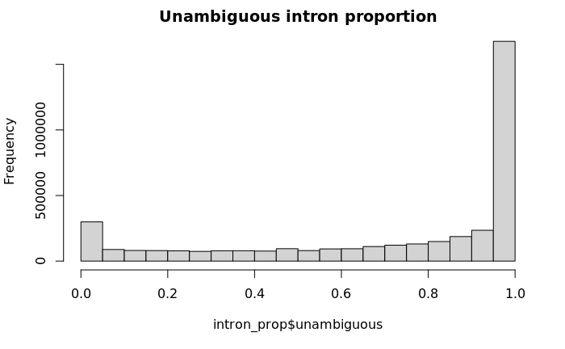

```r
depth <- list(unambiguous = as.matrix(nascent_counts + mature_counts),
              conservative = as.matrix(nascent_counts + mature_counts + ambiguous_counts))
intron_prop <- list(unambiguous = as.matrix(nascent_counts / depth$unambiguous),
                    conservative = as.matrix(nascent_counts / depth$conservative))

hist(intron_prop$unambiguous, main = "Unambiguous intron proportion")
```

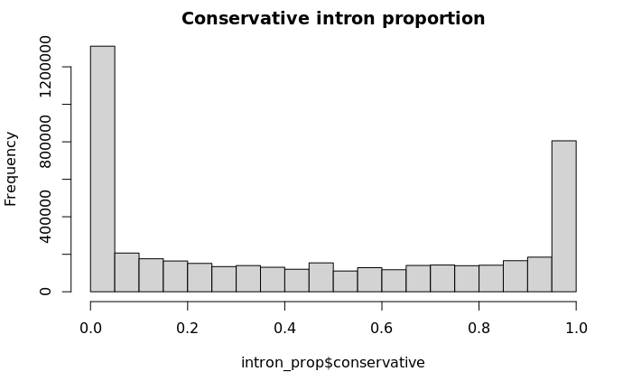

```r
hist(intron_prop$conservative, main = "Conservative intron proportion")
```

Gros excès de nascents globalement. Un élement d’explication est la plus grande taille des régions introniques

```r
sum_threshold <- 500
depth$filtered_unambiguous <- depth$unambiguous[rowSums(depth$unambiguous) > sum_threshold, ]

dim(depth$filtered_unambiguous)
```

```
[1] 28584   145
```

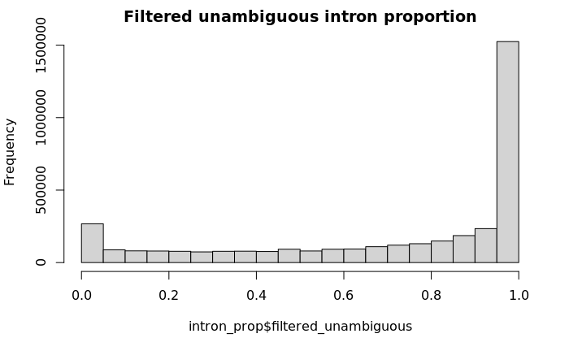

```r
intron_prop$filtered_unambiguous <- as.matrix(nascent_counts[rowSums(depth$unambiguous) > sum_threshold, ] / depth$filtered_unambiguous)
hist(intron_prop$filtered_unambiguous, main = "Filtered unambiguous intron proportion")
```

Conservation des lignes (gènes) avec un compte d’au moins 500 à travers les 145 samples. ~10 000 gènes sont exclus Un compte de 500 revient a une expression d’environ 3.5 dans chaque sample Tjs bcp de nascents par rapport aux matures. Bcp de gènes sont composés que de quelques introns (nascents)

## Comparaison des proportions moyennes d’introns (tous les gènes)

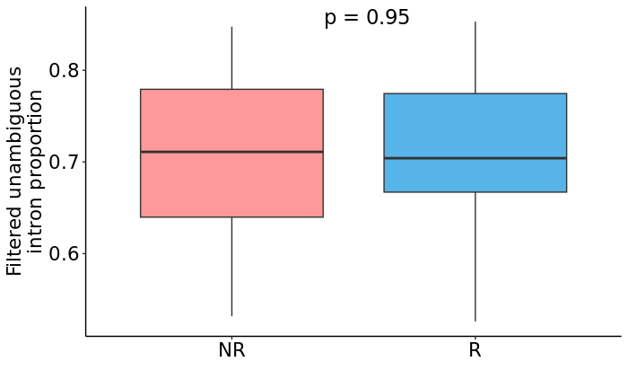

```r
col_mean <- data.frame(Mean = colMeans(intron_prop$filtered_unambiguous, na.rm = TRUE)) %>%
   rownames_to_column("Sample_ID") %>%
   inner_join(., design, by = "Sample_ID")

ggplot(col_mean, aes(Response, Mean, fill = Response)) +
   geom_boxplot() +
   scale_fill_manual(values = c("R" = "#56B4E9", "NR" = "#FF9999")) +
   theme_classic() +
   stat_compare_means(method = "wilcox.test", label.x = 1.45, vjust = 0.2, label = "p.format", size = 6) +
   theme(axis.text.x = element_text(size = 16, color = "black"),
         axis.text.y = element_text(size = 16, color = "black"),
         text = element_text(size = 16, color = "black"),
         strip.text = element_text(size = 16, color = "black"),
         legend.position = "bottom") +
   guides(fill = "none") +
   labs(y = "Filtered unambiguous\nintron proportion", x = "")
```

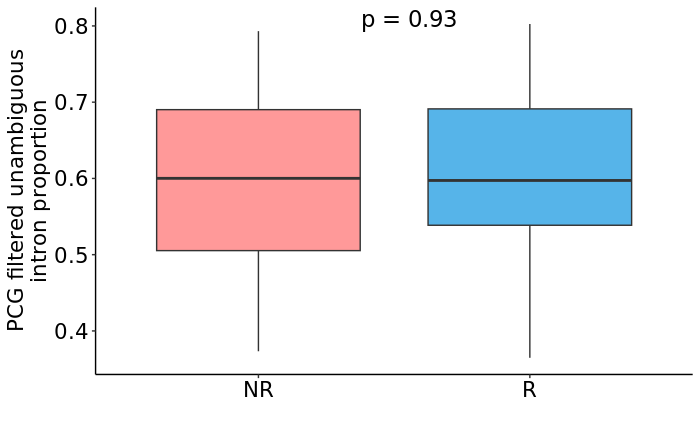

```r
subset <- as.data.frame(intron_prop$filtered_unambiguous) %>%
   rownames_to_column("Ensembl_gene_id") %>%
   filter(Ensembl_gene_id %in% pcg$Geneid) %>%
   column_to_rownames("Ensembl_gene_id")
col_mean <- data.frame(Mean = colMeans(subset, na.rm = TRUE)) %>%
   rownames_to_column("Sample_ID") %>%
   inner_join(., design, by = "Sample_ID")
ggplot(col_mean, aes(Response, Mean, fill = Response)) +
   geom_boxplot() +
   scale_fill_manual(values = c("R" = "#56B4E9", "NR" = "#FF9999")) +
   theme_classic() +
   stat_compare_means(method = "wilcox.test", label.x = 1.45, vjust = 0.2, label = "p.format", size = 6) +
   theme(axis.text.x = element_text(size = 16, color = "black"),
         axis.text.y = element_text(size = 16, color = "black"),
         text = element_text(size = 16, color = "black"),
         strip.text = element_text(size = 16, color = "black"),
         legend.position = "bottom") +
   guides(fill = "none") +
   labs(y = "PCG filtered unambiguous\nintron proportion", x = "")
```

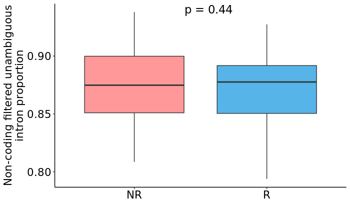

```r
subset <- as.data.frame(intron_prop$filtered_unambiguous) %>%
   rownames_to_column("Ensembl_gene_id") %>%
   filter(Ensembl_gene_id %in% non_coding$Geneid) %>%
   column_to_rownames("Ensembl_gene_id")
col_mean <- data.frame(Mean = colMeans(subset, na.rm = TRUE)) %>%
   rownames_to_column("Sample_ID") %>%
   inner_join(., design, by = "Sample_ID")
ggplot(col_mean, aes(Response, Mean, fill = Response)) +
   geom_boxplot() +
   scale_fill_manual(values = c("R" = "#56B4E9", "NR" = "#FF9999")) +
   theme_classic() +
   stat_compare_means(method = "wilcox.test", label.x = 1.45, vjust = 0.2, label = "p.format", size = 6) +
   theme(axis.text.x = element_text(size = 16, color = "black"),
         axis.text.y = element_text(size = 16, color = "black"),
         text = element_text(size = 16, color = "black"),
         strip.text = element_text(size = 16, color = "black"),
         legend.position = "bottom") +
   guides(fill = "none") +
   labs(y = "Non-coding filtered unambiguous\nintron proportion", x = "")
```

Pas de diff de proportions moyennes d’introns (dans le cas unambiguous) globalement, ni lorsqu’on stratifie par PCG et non-codant

## Comparaison des proportions moyennes d’introns (PCG diff exprimés)

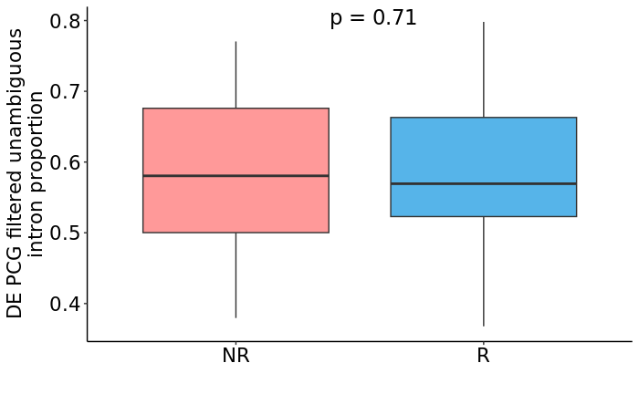

```r
de_pcg <- read_tsv("/mnt/beegfs/userdata/h_herrmann/mela_ici_response_results/analyze_gene_expression/gr1234/DEG/coding_deg.tsv", show_col_types = FALSE)

subset <- as.data.frame(intron_prop$filtered_unambiguous) %>%
   rownames_to_column("Ensembl_gene_id") %>%
   filter(Ensembl_gene_id %in% de_pcg$ensembl_gene_id) %>%
   column_to_rownames("Ensembl_gene_id")
col_mean <- data.frame(Mean = colMeans(subset, na.rm = TRUE)) %>%
   rownames_to_column("Sample_ID") %>%
   inner_join(., design, by = "Sample_ID")
ggplot(col_mean, aes(Response, Mean, fill = Response)) +
   geom_boxplot() +
   scale_fill_manual(values = c("R" = "#56B4E9", "NR" = "#FF9999")) +
   theme_classic() +
   stat_compare_means(method = "wilcox.test", label.x = 1.45, vjust = 0.2, label = "p.format", size = 6) +
   theme(axis.text.x = element_text(size = 16, color = "black"),
         axis.text.y = element_text(size = 16, color = "black"),
         text = element_text(size = 16, color = "black"),
         strip.text = element_text(size = 16, color = "black"),
         legend.position = "bottom") +
   guides(fill = "none") +
   labs(y = "DE PCG filtered unambiguous\nintron proportion", x = "")
```

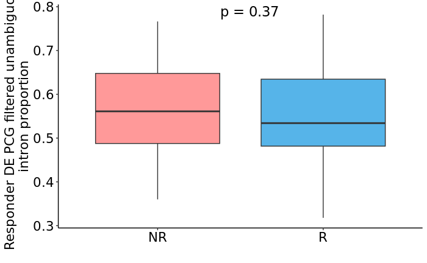

```r
subset <- as.data.frame(intron_prop$filtered_unambiguous) %>%
   rownames_to_column("Ensembl_gene_id") %>%
   filter(Ensembl_gene_id %in% (de_pcg %>% filter(Expression == "responder") %>% pull(ensembl_gene_id))) %>%
   column_to_rownames("Ensembl_gene_id")
col_mean <- data.frame(Mean = colMeans(subset, na.rm = TRUE)) %>%
   rownames_to_column("Sample_ID") %>%
   inner_join(., design, by = "Sample_ID")
ggplot(col_mean, aes(Response, Mean, fill = Response)) +
   geom_boxplot() +
   scale_fill_manual(values = c("R" = "#56B4E9", "NR" = "#FF9999")) +
   theme_classic() +
   stat_compare_means(method = "wilcox.test", label.x = 1.45, vjust = 0.2, label = "p.format", size = 6) +
   theme(axis.text.x = element_text(size = 16, color = "black"),
         axis.text.y = element_text(size = 16, color = "black"),
         text = element_text(size = 16, color = "black"),
         strip.text = element_text(size = 16, color = "black"),
         legend.position = "bottom") +
   guides(fill = "none") +
   labs(y = "Responder DE PCG filtered unambiguous\nintron proportion", x = "")
```

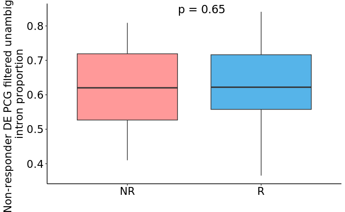

```r
subset <- as.data.frame(intron_prop$filtered_unambiguous) %>%
   rownames_to_column("Ensembl_gene_id") %>%
   filter(Ensembl_gene_id %in% (de_pcg %>% filter(Expression == "non_responder") %>% pull(ensembl_gene_id))) %>%
   column_to_rownames("Ensembl_gene_id")
col_mean <- data.frame(Mean = colMeans(subset, na.rm = TRUE)) %>%
   rownames_to_column("Sample_ID") %>%
   inner_join(., design, by = "Sample_ID")
ggplot(col_mean, aes(Response, Mean, fill = Response)) +
   geom_boxplot() +
   scale_fill_manual(values = c("R" = "#56B4E9", "NR" = "#FF9999")) +
   theme_classic() +
   stat_compare_means(method = "wilcox.test", label.x = 1.45, vjust = 0.2, label = "p.format", size = 6) +
   theme(axis.text.x = element_text(size = 16, color = "black"),
         axis.text.y = element_text(size = 16, color = "black"),
         text = element_text(size = 16, color = "black"),
         strip.text = element_text(size = 16, color = "black"),
         legend.position = "bottom") +
   guides(fill = "none") +
   labs(y = "Non-responder DE PCG filtered unambiguous\nintron proportion", x = "")
```

Pas de diff de proportions moyennes d’introns (dans le cas unambiguous) chez les PCG, ni lorsqu’on stratifie par les PCG exprimés par les repondeurs et les non-repondeurs

## Comparaison des proportions moyennes d’introns (non-codant diff exprimés)

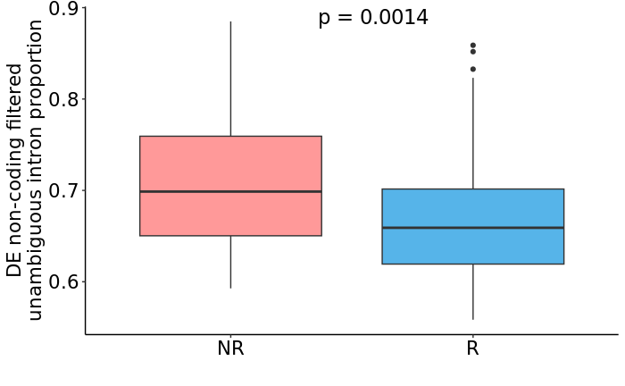

```r
de_non_coding <- read_tsv("/mnt/beegfs/userdata/h_herrmann/mela_ici_response_results/analyze_gene_expression/gr1234/DEG/non_coding_deg.tsv", show_col_types = FALSE)

subset <- as.data.frame(intron_prop$filtered_unambiguous) %>%
   rownames_to_column("Ensembl_gene_id") %>%
   filter(Ensembl_gene_id %in% de_non_coding$ensembl_gene_id) %>%
   column_to_rownames("Ensembl_gene_id")
col_mean <- data.frame(Mean = colMeans(subset, na.rm = TRUE)) %>%
   rownames_to_column("Sample_ID") %>%
   inner_join(., design, by = "Sample_ID")
ggplot(col_mean, aes(Response, Mean, fill = Response)) +
   geom_boxplot() +
   scale_fill_manual(values = c("R" = "#56B4E9", "NR" = "#FF9999")) +
   theme_classic() +
   stat_compare_means(method = "wilcox.test", label.x = 1.45, vjust = 0.2, label = "p.format", size = 6) +
   theme(axis.text.x = element_text(size = 16, color = "black"),
         axis.text.y = element_text(size = 16, color = "black"),
         text = element_text(size = 16, color = "black"),
         strip.text = element_text(size = 16, color = "black"),
         legend.position = "bottom") +
   guides(fill = "none") +
   labs(y = "DE non-coding filtered\nunambiguous intron proportion", x = "")
```

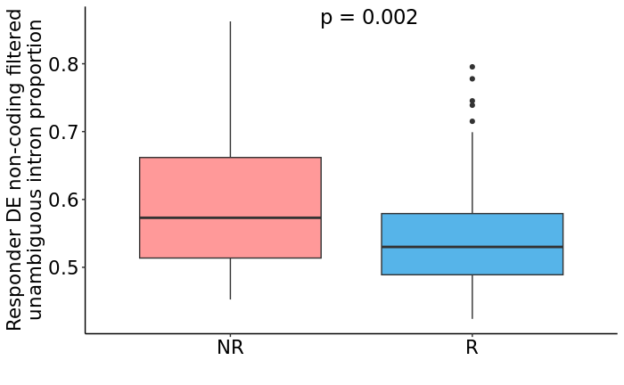

```r
subset <- as.data.frame(intron_prop$filtered_unambiguous) %>%
   rownames_to_column("Ensembl_gene_id") %>%
   filter(Ensembl_gene_id %in% (de_non_coding %>% filter(Expression == "responder") %>% pull(ensembl_gene_id))) %>%
   column_to_rownames("Ensembl_gene_id")
col_mean <- data.frame(Mean = colMeans(subset, na.rm = TRUE)) %>%
   rownames_to_column("Sample_ID") %>%
   inner_join(., design, by = "Sample_ID")
ggplot(col_mean, aes(Response, Mean, fill = Response)) +
   geom_boxplot() +
   scale_fill_manual(values = c("R" = "#56B4E9", "NR" = "#FF9999")) +
   theme_classic() +
   stat_compare_means(method = "wilcox.test", label.x = 1.45, vjust = 0.2, label = "p.format", size = 6) +
   theme(axis.text.x = element_text(size = 16, color = "black"),
         axis.text.y = element_text(size = 16, color = "black"),
         text = element_text(size = 16, color = "black"),
         strip.text = element_text(size = 16, color = "black"),
         legend.position = "bottom") +
   guides(fill = "none") +
   labs(y = "Responder DE non-coding filtered\nunambiguous intron proportion", x = "")
```

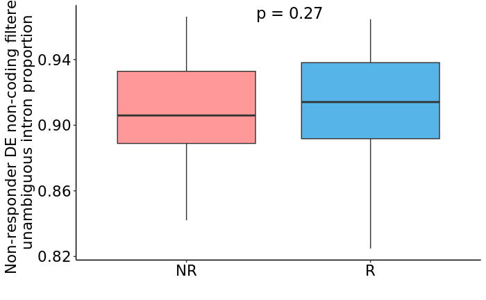

```r
subset <- as.data.frame(intron_prop$filtered_unambiguous) %>%
   rownames_to_column("Ensembl_gene_id") %>%
   filter(Ensembl_gene_id %in% (de_non_coding %>% filter(Expression == "non_responder") %>% pull(ensembl_gene_id))) %>%
   column_to_rownames("Ensembl_gene_id")
col_mean <- data.frame(Mean = colMeans(subset, na.rm = TRUE)) %>%
   rownames_to_column("Sample_ID") %>%
   inner_join(., design, by = "Sample_ID")
ggplot(col_mean, aes(Response, Mean, fill = Response)) +
   geom_boxplot() +
   scale_fill_manual(values = c("R" = "#56B4E9", "NR" = "#FF9999")) +
   theme_classic() +
   stat_compare_means(method = "wilcox.test", label.x = 1.45, vjust = 0.2, label = "p.format", size = 6) +
   theme(axis.text.x = element_text(size = 16, color = "black"),
         axis.text.y = element_text(size = 16, color = "black"),
         text = element_text(size = 16, color = "black"),
         strip.text = element_text(size = 16, color = "black"),
         legend.position = "bottom") +
   guides(fill = "none") +
   labs(y = "Non-responder DE non-coding filtered\nunambiguous intron proportion", x = "")
```

Parmi l’ensemble des gènes non-codants diff exprimés, il y a un excès d’introns par rapport aux exons chez les NR. Cet effet est retoruvé lorsqu’on stratifie par les gènes non-codants exprimés par les répondeurs, mais par lorsqu’on stratifie par les gènes des non-répondeurs

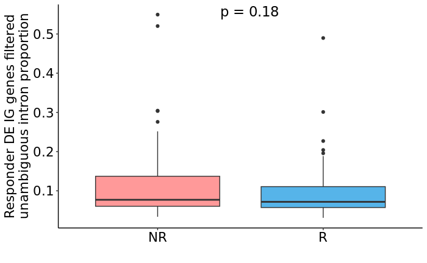

```r
de_ig <- de_non_coding %>% filter(Expression == "responder") %>%
   filter(grepl("IGK|IGH|IGL", hgnc_symbol))
de_without_ig <- de_non_coding %>% filter(Expression == "responder") %>%
   filter(!grepl("IGK|IGH|IGL", hgnc_symbol))

subset <- as.data.frame(intron_prop$filtered_unambiguous) %>%
   rownames_to_column("Ensembl_gene_id") %>%
   filter(Ensembl_gene_id %in% de_ig$ensembl_gene_id) %>%
   column_to_rownames("Ensembl_gene_id")
col_mean <- data.frame(Mean = colMeans(subset, na.rm = TRUE)) %>%
   rownames_to_column("Sample_ID") %>%
   inner_join(., design, by = "Sample_ID")
ggplot(col_mean, aes(Response, Mean, fill = Response)) +
   geom_boxplot() +
   scale_fill_manual(values = c("R" = "#56B4E9", "NR" = "#FF9999")) +
   theme_classic() +
   stat_compare_means(method = "wilcox.test", label.x = 1.45, vjust = 0.2, label = "p.format", size = 6) +
   theme(axis.text.x = element_text(size = 16, color = "black"),
         axis.text.y = element_text(size = 16, color = "black"),
         text = element_text(size = 16, color = "black"),
         strip.text = element_text(size = 16, color = "black"),
         legend.position = "bottom") +
   guides(fill = "none") +
   labs(y = "Responder DE IG genes filtered\nunambiguous intron proportion", x = "")
```

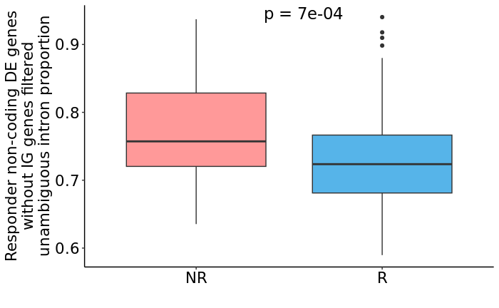

```r
subset <- as.data.frame(intron_prop$filtered_unambiguous) %>%
   rownames_to_column("Ensembl_gene_id") %>%
   filter(Ensembl_gene_id %in% de_without_ig$ensembl_gene_id) %>%
   column_to_rownames("Ensembl_gene_id")
col_mean <- data.frame(Mean = colMeans(subset, na.rm = TRUE)) %>%
   rownames_to_column("Sample_ID") %>%
   inner_join(., design, by = "Sample_ID")
ggplot(col_mean, aes(Response, Mean, fill = Response)) +
   geom_boxplot() +
   scale_fill_manual(values = c("R" = "#56B4E9", "NR" = "#FF9999")) +
   theme_classic() +
   stat_compare_means(method = "wilcox.test", label.x = 1.45, vjust = 0.2, label = "p.format", size = 6) +
   theme(axis.text.x = element_text(size = 16, color = "black"),
         axis.text.y = element_text(size = 16, color = "black"),
         text = element_text(size = 16, color = "black"),
         strip.text = element_text(size = 16, color = "black"),
         legend.position = "bottom") +
   guides(fill = "none") +
   labs(y = "Responder non-coding DE genes\nwithout IG genes filtered\nunambiguous intron proportion", x = "")
```

Pas d’excès d’introns lorsqu’on stratifie pour les gènes d’IG Mais excès lorsqu’on prend les gènes non-codants DE up chez les répondeurs. Toute petite pvalue pour une différence pas si importante

```r
as.data.frame(intron_prop$filtered_unambiguous) %>%
   rownames_to_column("ensembl_gene_id") %>%
   filter(ensembl_gene_id %in% de_without_ig$ensembl_gene_id) %>%
   inner_join(de_non_coding, ., by = "ensembl_gene_id") %>%
   pull(hgnc_symbol)
```

```
  [1] "PNISR-AS1"    "CFLAR-AS1"    "EML4-AS1"     "PAXIP1-AS2"   "PINK1-AS"     "ANXA2R-AS1"   NA             "ZNF710-AS1"   "LINC01176"    "LINC00426"
 [11] "CARD8-AS1"    NA             "LINC02978"    NA             "IL10RB-DT"    "PSMD14-DT"    "LUCAT1"       "LINC00299"    "LINC02908"    "IL21R-AS1"
 [21] "LINC02481"    "DOCK8-AS2"    NA             "IRF1-AS1"     NA             "TRG-AS1"      NA             NA             "DDHD1-DT"     NA
 [31] "DTNB-AS1"     NA             NA             "TPRG1-AS1"    NA             "LINC02937"    "LINC00612"    "SLC9A9-AS1"   NA             "ZMIZ1-AS1"
 [41] "MIR155HG"     "RRN3P2"       "SENCR"        NA             NA             NA             "LINC02975"    "PCED1B-AS1"   NA             "FAM157D"
 [51] NA             "LINC02863"    NA             NA             "LINC01678"    "SLC1A3-AS1"   "LINC02968"    "IGSF22-AS1"   NA             "FMNL1-DT"
 [61] "PHACTR2-AS1"  "TSPOAP1-AS1"  "DIO3OS"       "HCP5"         "LINC02416"    NA             NA             "LINC03058"    "ELMO1-AS1"    "PDLIM7-AS1"
 [71] NA             NA             "LINC02561"    "TFAP2E-AS1"   NA             NA             "SKAP1-AS2"    "LINC01691"    NA             "MYCL-AS1"
 [81] "TRGV9"        NA             NA             "CCR5AS"       NA             "LINC02580"    "IFNG-AS1"     NA             NA             "MIR223HG"
 [91] NA             NA             "ITGB2-AS1"    "LINC01934"    "TRGV5"        "LINC03034"    "SLC22A18AS"   NA             "KCNJ5-AS1"    NA
[101] NA             NA             "CYLD-AS1"     NA             "SLC39A13-AS1" NA             NA             "MMP2-AS1"     "LINC01806"    "MIAT"
[111] NA             "LINC01624"    NA             NA             "SIRPG-AS1"    NA             NA             "TRAV12-3"     NA             "AOAH-IT1"
[121] "MBNL1-AS1"    "DBH-AS1"      "TRGV3"        "LINC02325"    "HSD11B1-AS1"  "LINC00861"    NA             "LINC01374"    "HLA-DQB1-AS1" NA
[131] NA             "TRAV8-4"      NA             NA             "OVAAL"        NA             "TRBV15"       NA             "CORO1A-AS1"   "TRBV6-1"
[141] "NRXN2-AS1"    "LINC02303"    "CCND2-AS1"    NA             "USP30-AS1"    NA             "TRBV23-1"     "LINC03062"    "TRBV10-3"     "TRBV7-3"
[151] "PTPRN2-AS1"   "LINC02694"    "COPDA1"       NA             NA             NA             "TRGV1"        "TRBV4-2"      "IL21-AS1"     NA
[161] "TRBV3-1"      "TRAV17"       "PIK3R5-DT"    NA             NA             "TRBV29-1"     "LINC02446"    "TRAV9-2"      "TRAV29DV5"    "TRAV26-1"
[171] NA             "TRBV7-2"      "LINC01724"    NA             "TRAV22"       "TRAV27"       "TRGV2"        "LINC01871"    "TRBV12-3"     "TRAC"
[181] "TRBV7-6"      "TRAV38-2DV8"  "LINC02312"    "TRAV4"        "TRBV2"        "TRBV6-6"      "TRBV30"       "LINC01857"    "FAM30A"       "TRAV8-2"
[191] "TRAV13-1"     "TRBV27"       NA             "TRBC2"        "TRAV19"       NA             "TRAV20"       NA             "TRAV21"       "TRBV4-1"
[201] "TRBV12-4"     "TRBC1"        "TRAV12-2"     "TRDC"         "TRGC2"        "TRAV8-6"      "TRBV9"        "TRAV14DV4"    "TRBV14"       NA
[211] "TRBV5-1"      "TRBV6-2"      NA             "TRBV20-1"     "TRBV11-2"     "TRBV7-9"      "TRAV3"        "TRBV18"       NA             "TRBV19"
[221] "TRBV5-6"      "TRAV13-2"     "LINC02300"    "TRBV6-5"      "LINC01918"    "TRAV2"        "IQSEC3-AS2"   "TRAV1-2"      NA             "TRAV5"
[231] "LINC02484"    "LINC02748"
```

A noter que IFNG-AS1 est up chez les répondeurs. Il s’agit bien de l’AS d’IFNG, qui agit en régulateur positif de l’expression d’IFNG Stein N, Berhani O, Schmiedel D, Duev-Cohen A, Seidel E, Kol I, et al. (January 2019). “IFNG-AS1 Enhances Interferon Gamma Production in Human Natural Killer Cells”. iScience. 11: 466–473. Bibcode:2019iSci…11..466S. doi:10.1016/j.isci.2018.12.034. PMC 6354656. PMID 30661002

```r
de_annotation <- as.data.frame(intron_prop$filtered_unambiguous) %>%
   rownames_to_column("ensembl_gene_id") %>%
   filter(ensembl_gene_id %in% de_without_ig$ensembl_gene_id) %>%
   inner_join(de_non_coding, ., by = "ensembl_gene_id") %>%
   inner_join(annotation, ., by = c("Geneid" = "ensembl_gene_id")) %>%
   mutate(Antisens = grepl("-AS", hgnc_symbol))
table(de_annotation$Class, useNA = "always")
```

```
   lncRNA TR_C_gene TR_V_gene      <NA>
       95         5        55        77
```

```r
table(de_annotation$Class, de_annotation$Antisens, deparse.level = 2, useNA = "always")
```

```
                   de_annotation$Antisens
de_annotation$Class FALSE TRUE <NA>
          lncRNA       54   41    0
          TR_C_gene     5    0    0
          TR_V_gene    55    0    0
          <NA>         74    3    0
```

TR correspond à T cell receptor Environ 40% des lncRNA sont des antisens

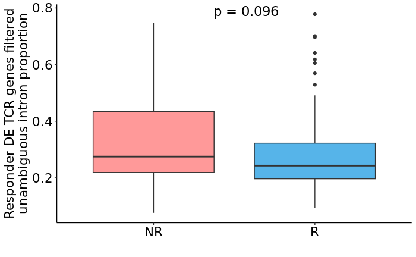

```r
de_tcr <- de_non_coding %>% filter(Expression == "responder") %>%
   filter(grepl("TRA|TRB|TRD|TRG", hgnc_symbol))
de_without_tcr <- de_non_coding %>% filter(Expression == "responder") %>%
   filter(!grepl("TRA|TRB|TRD|TRG", hgnc_symbol))
de_lnc <- de_annotation %>% filter(Expression == "responder") %>%
   filter(grepl("lncRNA", Class))
de_na <- de_annotation %>% filter(Expression == "responder") %>%
   filter(is.na(Class))

subset <- as.data.frame(intron_prop$filtered_unambiguous) %>%
   rownames_to_column("Ensembl_gene_id") %>%
   filter(Ensembl_gene_id %in% de_tcr$ensembl_gene_id) %>%
   column_to_rownames("Ensembl_gene_id")
col_mean <- data.frame(Mean = colMeans(subset, na.rm = TRUE)) %>%
   rownames_to_column("Sample_ID") %>%
   inner_join(., design, by = "Sample_ID")
ggplot(col_mean, aes(Response, Mean, fill = Response)) +
   geom_boxplot() +
   scale_fill_manual(values = c("R" = "#56B4E9", "NR" = "#FF9999")) +
   theme_classic() +
   stat_compare_means(method = "wilcox.test", label.x = 1.45, vjust = 0.2, label = "p.format", size = 6) +
   theme(axis.text.x = element_text(size = 16, color = "black"),
         axis.text.y = element_text(size = 16, color = "black"),
         text = element_text(size = 16, color = "black"),
         strip.text = element_text(size = 16, color = "black"),
         legend.position = "bottom") +
   guides(fill = "none") +
   labs(y = "Responder DE TCR genes filtered\nunambiguous intron proportion", x = "")
```

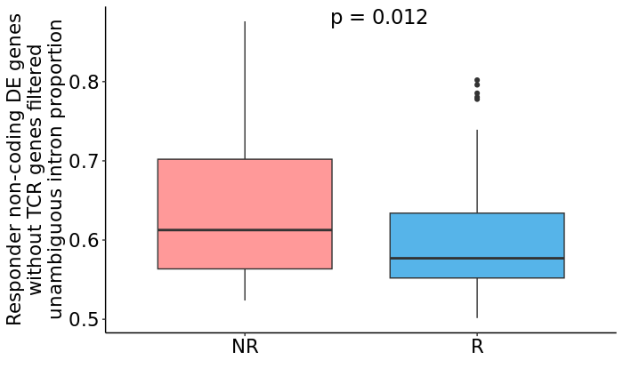

```r
subset <- as.data.frame(intron_prop$filtered_unambiguous) %>%
   rownames_to_column("Ensembl_gene_id") %>%
   filter(Ensembl_gene_id %in% de_without_tcr$ensembl_gene_id) %>%
   column_to_rownames("Ensembl_gene_id")
col_mean <- data.frame(Mean = colMeans(subset, na.rm = TRUE)) %>%
   rownames_to_column("Sample_ID") %>%
   inner_join(., design, by = "Sample_ID")
ggplot(col_mean, aes(Response, Mean, fill = Response)) +
   geom_boxplot() +
   scale_fill_manual(values = c("R" = "#56B4E9", "NR" = "#FF9999")) +
   theme_classic() +
   stat_compare_means(method = "wilcox.test", label.x = 1.45, vjust = 0.2, label = "p.format", size = 6) +
   theme(axis.text.x = element_text(size = 16, color = "black"),
         axis.text.y = element_text(size = 16, color = "black"),
         text = element_text(size = 16, color = "black"),
         strip.text = element_text(size = 16, color = "black"),
         legend.position = "bottom") +
   guides(fill = "none") +
   labs(y = "Responder non-coding DE genes\nwithout TCR genes filtered\nunambiguous intron proportion", x = "")
```

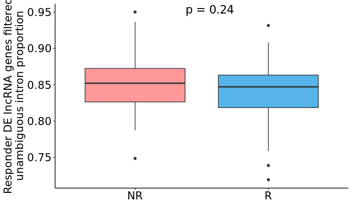

```r
subset <- as.data.frame(intron_prop$filtered_unambiguous) %>%
   rownames_to_column("Ensembl_gene_id") %>%
   filter(Ensembl_gene_id %in% de_lnc$Geneid) %>%
   column_to_rownames("Ensembl_gene_id")
col_mean <- data.frame(Mean = colMeans(subset, na.rm = TRUE)) %>%
   rownames_to_column("Sample_ID") %>%
   inner_join(., design, by = "Sample_ID")
ggplot(col_mean, aes(Response, Mean, fill = Response)) +
   geom_boxplot() +
   scale_fill_manual(values = c("R" = "#56B4E9", "NR" = "#FF9999")) +
   theme_classic() +
   stat_compare_means(method = "wilcox.test", label.x = 1.45, vjust = 0.2, label = "p.format", size = 6) +
   theme(axis.text.x = element_text(size = 16, color = "black"),
         axis.text.y = element_text(size = 16, color = "black"),
         text = element_text(size = 16, color = "black"),
         strip.text = element_text(size = 16, color = "black"),
         legend.position = "bottom") +
   guides(fill = "none") +
   labs(y = "Responder DE lncRNA genes filtered\nunambiguous intron proportion", x = "")
```

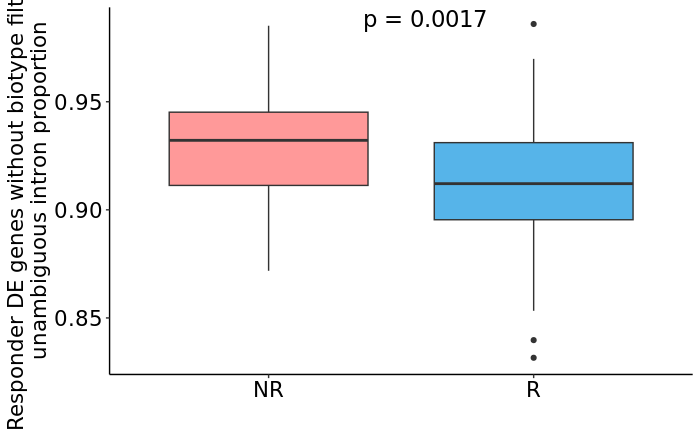

```r
subset <- as.data.frame(intron_prop$filtered_unambiguous) %>%
   rownames_to_column("Ensembl_gene_id") %>%
   filter(Ensembl_gene_id %in% de_na$Geneid) %>%
   column_to_rownames("Ensembl_gene_id")
col_mean <- data.frame(Mean = colMeans(subset, na.rm = TRUE)) %>%
   rownames_to_column("Sample_ID") %>%
   inner_join(., design, by = "Sample_ID")
ggplot(col_mean, aes(Response, Mean, fill = Response)) +
   geom_boxplot() +
   scale_fill_manual(values = c("R" = "#56B4E9", "NR" = "#FF9999")) +
   theme_classic() +
   stat_compare_means(method = "wilcox.test", label.x = 1.45, vjust = 0.2, label = "p.format", size = 6) +
   theme(axis.text.x = element_text(size = 16, color = "black"),
         axis.text.y = element_text(size = 16, color = "black"),
         text = element_text(size = 16, color = "black"),
         strip.text = element_text(size = 16, color = "black"),
         legend.position = "bottom") +
   guides(fill = "none") +
   labs(y = "Responder DE genes without biotype filtered\nunambiguous intron proportion", x = "")
```